# lab6

Derek Maldonado

4/11/2021

## Question 1

Section 12.3.3 from your textbook refers to: The problem with replications of a meaningless experiment: ‘alpha and the captain’s age.’ The issue here is that if you run an ineffectual experiment enough times you can always find a significant result by chance. The textbook mentions that if you repeat an experiment 20 times, you are guaranteed to find a significant result with .64 probability, and the probability is .92 if you repeat the experiment 50 times

```r
# a) use rbinom() to show I can reproduce both probabilities

p1 <- replicate(1000, sum(rbinom(20, 1, 0.05)))

length(p1[p1 > 0])/1000
```

```
## [1] 0.629
```

```r
#very close to 0.64

p2 <- replicate(1000, sum(rbinom(50,1,0.05)))

length(p2[p2 > 0])/1000
```

```
## [1] 0.91
```

```r
#very close to 0.92

# b) if conducted 20 times with 4 groups and the experimenter would accept a sig result from any contrast, what would be probability of finding a sig result here?

b1 <- replicate(1000, sum(rbinom(20,3,0.05)))

length(b1[b1 > 0])/1000
```

```
## [1] 0.961
```

```r
#50% did part a alone, didn't understand part b that much
```

## Question 2

Consider that a researcher publishes a study showing a significant effect, p <. 05; but, in reality the researcher makes a type I error, and the manipulation did not cause any difference. If many other researchers replicated the study, what kind of p-values would they find? Use R to create a sampling distribution of p-values that would be expected in this situation. What shape does this distribution have?

```r
library(tibble)
```

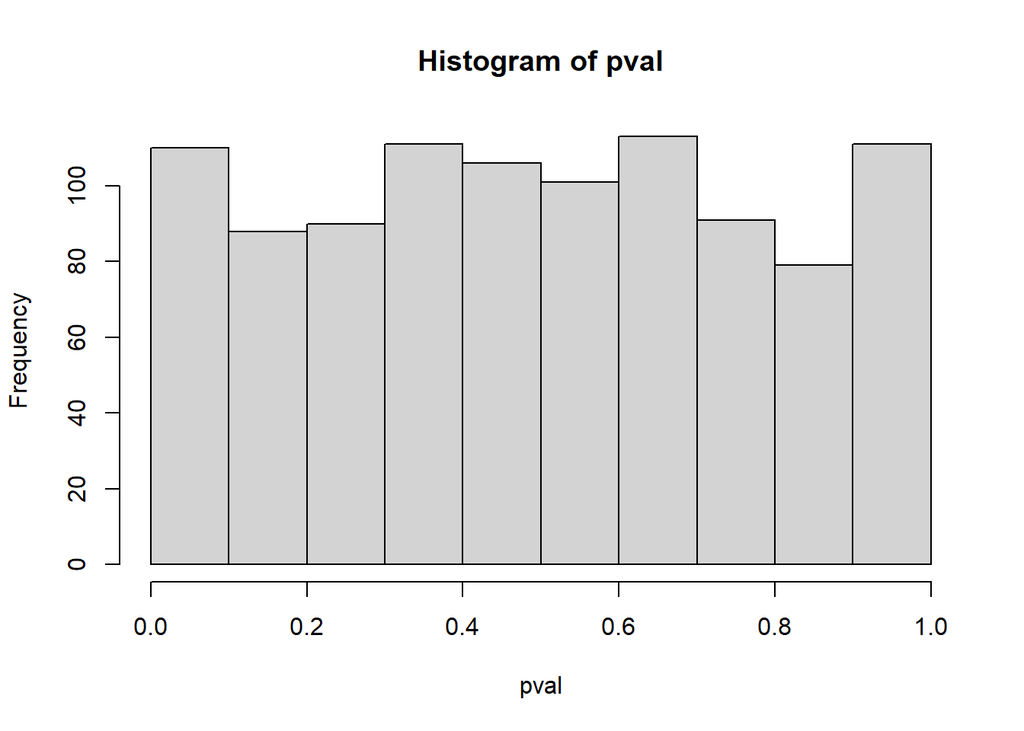

```r
library(ggplot2)
pval <- c()
for(i in 1:1000){
  d <- rnorm(100, 0, 1)
  e <- rnorm(100, 0 ,1)
  dv <- c(d,e)

  iv <- rep(1:2, 100)
  exp <- tibble(iv,dv)

  pval[i] <- t.test(dv~iv, var.equal=TRUE, data = exp)$p.value
}

hist(pval)
```

```r
length(pval[pval < 0.05])/1000
```

```
## [1] 0.057
```

```r
#looks real level from here. 50% had the idea, but thought I was going to need to ggplot it and messed up that part
```

## Question 3

Now assume that the published result reflects a true effect. Specifically, let’s imagine the study had two groups (between-subjects), with 20 subjects in each group. Assume that scores for subjects are all sampled from a normal distribution, and that group A has larger mean than group B by .5 standard deviations (e.g., Cohen’s d = .5). If many other researchers replicated the study, what kind of p-values would they find? Use R to create a sampling distribution of p-values that would be expected in this situation. What shape does this distribution have?

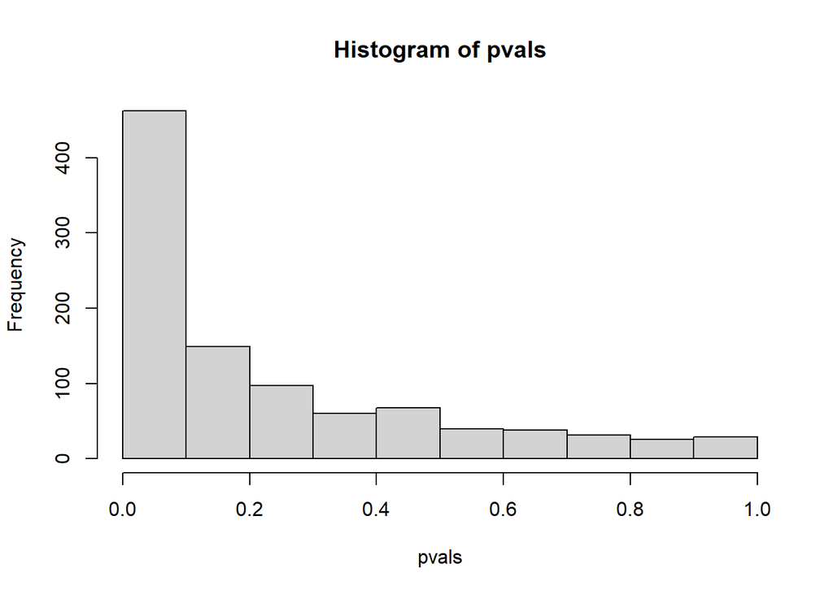

```r
f <- rnorm(20, 0, 1)
g <- rnorm(20, 0.5, 1)
dv <- c(f,g)
iv <- iv <- rep(1:2, each=20)
ex2 <- tibble(iv,dv)

#pvals <- replicate(1000,t.test(f,g, var.equal = TRUE)$p.value)
pvals <- replicate(1000, t.test(rnorm(20,0.5,1),rnorm(20,0,1),var.equal = TRUE)$p.value)

hist(pvals)
```